# Predicting Selling Price of a House

# 1 Background

In this project I will develop a model to predict the selling price of a given home in Ames, Iowa. My aim here is to figure out whether the asking/current price of the house is higher or lower than the true value of the house. If the home is undervalued, it can be considered a good investment.

# 2 Training Data and relevant packages

In order to better assess the quality of the model I have divided the data randomly into three separate pieces: a training data set, a testing data set, and a validation data set. Before we proceed further I will give a brief about the data set.

TYPE: Population SIZE: 2930 observations, 82 variables

DESCRIPTIVE ABSTRACT: Data set contains information from the Ames Assessor’s Office used in computing assessed values for individual residential properties sold in Ames, IA from 2006 to 2010.

VARIABLE DESCRIPTIONS: The data has 82 columns which include 23 nominal, 23 ordinal, 14 discrete, and 20 continuous variables (and 2 additional observation identifiers). Some of the important varibales have been explained below - Lot Area (Continuous): Lot size in square feet

- Utilities (Ordinal): Type of utilities available, 4 classifications
- Neighborhood (Nominal): Physical locations within Ames city limits, 27 values
- Overall Qual (Ordinal): Rates the overall material and finish of the house, 10 classifications from 1-10
- Overall Cond (Ordinal): Rates the overall condition of the house, 10 classifications from 1-10
- Year Built (Discrete): Original construction date
- Total Bsmt SF (Continuous): Total square feet of basement area
- Heating (Nominal): Type of heating, 6 values
- 1st Flr SF (Continuous): First Floor square feet
- 2nd Flr SF (Continuous) : Second floor square feet
- Garage Area (Continuous): Size of garage in square feet
- Garage Qual (Ordinal): Garage quality, 6 classifications
- Pool Area (Continuous): Pool area in square feet
- SalePrice (Continuous): Sale price

First I’ll the load training data set.

```r
load("ames_train.Rdata")
```

Next; import all the appropriate packages.

```r
library(dplyr)
library(BAS)
library(ggplot2)
library(stats)
library(MASS)
```

dplyr: For exploratory data analysis and manipulation. ggplot2: For making plots. stats: For statistical calculations. BAS: For Bayesian Model Averaging and Model Selection.

# 3 Exploratory Data Analysis (EDA)

## 3.1 Trimming the data set

It is very important to explore the structure of the data and the relationships between the variables in the data set before starting modelling. For example, we might need to transform some variables, remove the NA/Empty values from the dataset.

Therefore, first I’ll look at the price because since it is a continuous variable which has a very wide range, it might need to be transformed.

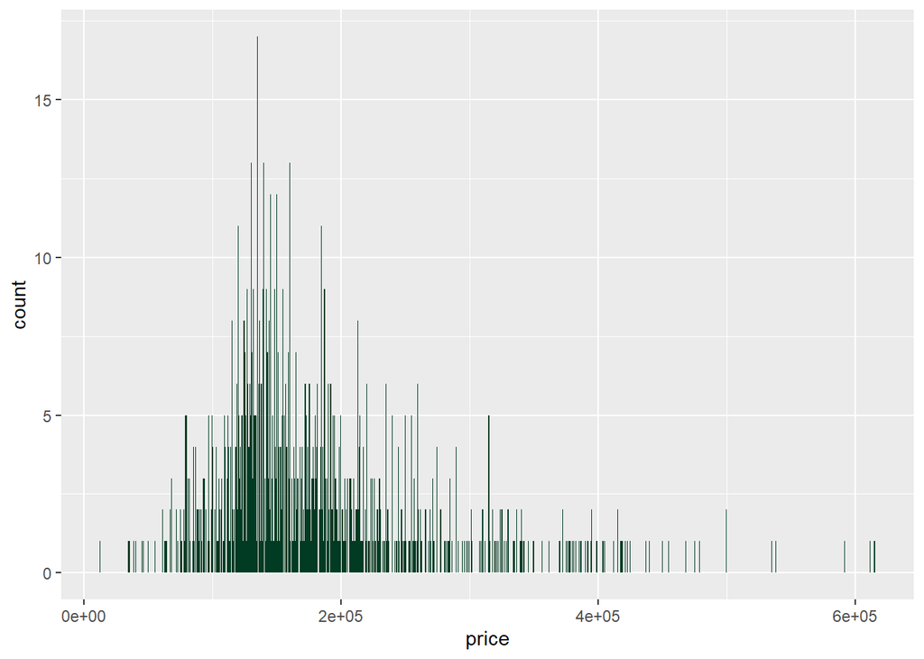

```r
ggplot(ames_train, aes(x=price)) + geom_bar(binwidth = 600,fill = "#013B23")
```

The distribution is right skewed, and hence we tranform it to log(price).

```r
ames_train<- ames_train %>% mutate(log_price=log(price))
```

Before we proceed with the EDA, we should assess the number of NA values in each varibale.

```r
missing_list <- colSums(is.na(ames_train))
missing_list <- sort(missing_list, decreasing = TRUE)
head(missing_list,81)
```

```
##         Pool.QC    Misc.Feature           Alley           Fence    Fireplace.Qu
##             997             971             933             798             491
##    Lot.Frontage   Garage.Yr.Blt     Garage.Qual     Garage.Cond     Garage.Type
##             167              48              47              47              46
##   Garage.Finish       Bsmt.Qual       Bsmt.Cond   Bsmt.Exposure  BsmtFin.Type.1
##              46              21              21              21              21
##  BsmtFin.Type.2    Mas.Vnr.Area    BsmtFin.SF.1    BsmtFin.SF.2     Bsmt.Unf.SF
##              21               7               1               1               1
##   Total.Bsmt.SF  Bsmt.Full.Bath  Bsmt.Half.Bath     Garage.Cars     Garage.Area
##               1               1               1               1               1
##             PID            area           price     MS.SubClass       MS.Zoning
##               0               0               0               0               0
##        Lot.Area          Street       Lot.Shape    Land.Contour       Utilities
##               0               0               0               0               0
##      Lot.Config      Land.Slope    Neighborhood     Condition.1     Condition.2
##               0               0               0               0               0
##       Bldg.Type     House.Style    Overall.Qual    Overall.Cond      Year.Built
##               0               0               0               0               0
##  Year.Remod.Add      Roof.Style       Roof.Matl    Exterior.1st    Exterior.2nd
##               0               0               0               0               0
##    Mas.Vnr.Type      Exter.Qual      Exter.Cond      Foundation         Heating
##               0               0               0               0               0
##      Heating.QC     Central.Air      Electrical     X1st.Flr.SF     X2nd.Flr.SF
##               0               0               0               0               0
## Low.Qual.Fin.SF       Full.Bath       Half.Bath   Bedroom.AbvGr   Kitchen.AbvGr
##               0               0               0               0               0
##    Kitchen.Qual   TotRms.AbvGrd      Functional      Fireplaces     Paved.Drive
##               0               0               0               0               0
##    Wood.Deck.SF   Open.Porch.SF  Enclosed.Porch     X3Ssn.Porch    Screen.Porch
##               0               0               0               0               0
##       Pool.Area        Misc.Val         Mo.Sold         Yr.Sold       Sale.Type
##               0               0               0               0               0
##  Sale.Condition
##               0
```

```r
str(ames_train)
```

```
## Classes 'tbl_df', 'tbl' and 'data.frame':    1000 obs. of  82 variables:
##  $ PID            : int  909176150 905476230 911128020 535377150 534177230 908128060 902135020 528228540 923426010 908186050 ...
##  $ area           : int  856 1049 1001 1039 1665 1922 936 1246 889 1072 ...
##  $ price          : int  126000 139500 124900 114000 227000 198500 93000 187687 137500 140000 ...
##  $ MS.SubClass    : int  30 120 30 70 60 85 20 20 20 180 ...
##  $ MS.Zoning      : Factor w/ 7 levels "A (agr)","C (all)",..: 6 6 2 6 6 6 7 6 6 7 ...
##  $ Lot.Frontage   : int  NA 42 60 80 70 64 60 53 74 35 ...
##  $ Lot.Area       : int  7890 4235 6060 8146 8400 7301 6000 3710 12395 3675 ...
##  $ Street         : Factor w/ 2 levels "Grvl","Pave": 2 2 2 2 2 2 2 2 2 2 ...
##  $ Alley          : Factor w/ 2 levels "Grvl","Pave": NA NA NA NA NA NA 2 NA NA NA ...
##  $ Lot.Shape      : Factor w/ 4 levels "IR1","IR2","IR3",..: 4 4 4 4 4 4 4 4 4 4 ...
##  $ Land.Contour   : Factor w/ 4 levels "Bnk","HLS","Low",..: 4 4 4 4 4 4 1 4 4 4 ...
##  $ Utilities      : Factor w/ 3 levels "AllPub","NoSeWa",..: 1 1 1 1 1 1 1 1 1 1 ...
##  $ Lot.Config     : Factor w/ 5 levels "Corner","CulDSac",..: 1 5 5 1 5 1 5 5 1 5 ...
##  $ Land.Slope     : Factor w/ 3 levels "Gtl","Mod","Sev": 1 1 1 1 1 1 2 1 1 1 ...
```

[output cut: 68 more lines]

We have to remove Pool.QC ,Misc.Feature ,Alley,Fence,Fireplace.Qu ,Lot.Frontage beacuse they have too many NA vlaues which will hamper our model.

```r
cols.dont.want <- "Fireplace.Qu"
ames_train <- ames_train[, ! names(ames_train) %in% cols.dont.want]
cols.dont.want <- "Fence"
ames_train <- ames_train[, ! names(ames_train) %in% cols.dont.want]
cols.dont.want <- "Alley"
ames_train <- ames_train[, ! names(ames_train) %in% cols.dont.want]
cols.dont.want <- "Misc.Feature"
ames_train <- ames_train[, ! names(ames_train) %in% cols.dont.want]
cols.dont.want <- "Pool.QC"
ames_train <- ames_train[, ! names(ames_train) %in% cols.dont.want]
cols.dont.want <- "Lot.Frontage"
ames_train <- ames_train[, ! names(ames_train) %in% cols.dont.want]

summary(ames_train)
```

```
##       PID                 area          price         MS.SubClass
##  Min.   :5.263e+08   Min.   : 334   Min.   : 12789   Min.   : 20.00
##  1st Qu.:5.285e+08   1st Qu.:1092   1st Qu.:129763   1st Qu.: 20.00
##  Median :5.354e+08   Median :1411   Median :159467   Median : 50.00
##  Mean   :7.059e+08   Mean   :1477   Mean   :181190   Mean   : 57.15
##  3rd Qu.:9.071e+08   3rd Qu.:1743   3rd Qu.:213000   3rd Qu.: 70.00
##  Max.   :1.007e+09   Max.   :4676   Max.   :615000   Max.   :190.00
##
##    MS.Zoning      Lot.Area       Street    Lot.Shape Land.Contour  Utilities
##  A (agr):  0   Min.   :  1470   Grvl:  3   IR1:338   Bnk: 33      AllPub:1000
##  C (all):  9   1st Qu.:  7314   Pave:997   IR2: 30   HLS: 38      NoSeWa:   0
##  FV     : 56   Median :  9317              IR3:  3   Low: 20      NoSewr:   0
##  I (all):  1   Mean   : 10352              Reg:629   Lvl:909
##  RH     :  7   3rd Qu.: 11650
##  RL     :772   Max.   :215245
##  RM     :155
##    Lot.Config  Land.Slope  Neighborhood  Condition.1   Condition.2
##  Corner :173   Gtl:962    NAmes  :155   Norm   :875   Norm   :988
##  CulDSac: 76   Mod: 33    CollgCr: 85   Feedr  : 53   Feedr  :  6
##  FR2    : 36   Sev:  5    Somerst: 74   Artery : 23   Artery :  2
##  FR3    :  5              OldTown: 71   RRAn   : 14   PosN   :  2
##  Inside :710              Sawyer : 61   PosN   : 11   PosA   :  1
##                           Edwards: 60   RRAe   : 11   RRNn   :  1
##                           (Other):494   (Other): 13   (Other):  0
##   Bldg.Type    House.Style   Overall.Qual     Overall.Cond     Year.Built
##  1Fam  :823   1Story :521   Min.   : 1.000   Min.   :1.000   Min.   :1872
##  2fmCon: 20   2Story :286   1st Qu.: 5.000   1st Qu.:5.000   1st Qu.:1955
##  Duplex: 35   1.5Fin : 98   Median : 6.000   Median :5.000   Median :1975
##  Twnhs : 38   SLvl   : 41   Mean   : 6.095   Mean   :5.559   Mean   :1972
##  TwnhsE: 84   SFoyer : 36   3rd Qu.: 7.000   3rd Qu.:6.000   3rd Qu.:2001
##               2.5Unf : 10   Max.   :10.000   Max.   :9.000   Max.   :2010
##               (Other):  8
##  Year.Remod.Add   Roof.Style    Roof.Matl    Exterior.1st  Exterior.2nd
##  Min.   :1950   Flat   :  9   CompShg:984   VinylSd:349   VinylSd:345
##  1st Qu.:1966   Gable  :775   Tar&Grv: 11   HdBoard:164   HdBoard:150
##  Median :1992   Gambrel:  8   WdShake:  2   MetalSd:147   MetalSd:148
##  Mean   :1984   Hip    :204   WdShngl:  2   Wd Sdng:138   Wd Sdng:130
##  3rd Qu.:2004   Mansard:  4   Metal  :  1   Plywood: 74   Plywood: 96
##  Max.   :2010   Shed   :  0   ClyTile:  0   CemntBd: 40   CmentBd: 40
##                               (Other):  0   (Other): 88   (Other): 91
```

[output cut: 73 more lines]

```
##  Min.   :  0.000   Min.   :    0.00   Min.   : 1.000   Min.   :2006
##  1st Qu.:  0.000   1st Qu.:    0.00   1st Qu.: 4.000   1st Qu.:2007
##  Median :  0.000   Median :    0.00   Median : 6.000   Median :2008
##  Mean   :  1.463   Mean   :   45.81   Mean   : 6.243   Mean   :2008
##  3rd Qu.:  0.000   3rd Qu.:    0.00   3rd Qu.: 8.000   3rd Qu.:2009
##  Max.   :800.000   Max.   :15500.00   Max.   :12.000   Max.   :2010
##
##    Sale.Type   Sale.Condition   log_price
##  WD     :863   Abnorml: 61    Min.   : 9.456
##  New    : 79   AdjLand:  2    1st Qu.:11.773
##  COD    : 27   Alloca :  4    Median :11.980
##  ConLD  :  7   Family : 17    Mean   :12.018
##  ConLw  :  6   Normal :834    3rd Qu.:12.269
##  Con    :  5   Partial: 82    Max.   :13.329
##  (Other): 13
```

From the summary table it is evident that the utlities has only one factor which is AllPub so Utilities can be removed from the data frame.

```r
summary(ames_train $Misc.Val)
```

```
##     Min.  1st Qu.   Median     Mean  3rd Qu.     Max.
##     0.00     0.00     0.00    45.81     0.00 15500.00
```

```r
j1 <- ames_train %>% filter(Misc.Val==0)%>% summarise(n=n())
j1
```

```
## # A tibble: 1 x 1
##       n
##   <int>
## 1   971
```

Misc.Val takes the value of zero for 971 times and hence it should also be removed from the data frame.

```r
summary(ames_train $Pool.Area)
```

```
##    Min. 1st Qu.  Median    Mean 3rd Qu.    Max.
##   0.000   0.000   0.000   1.463   0.000 800.000
```

```r
p1 <- ames_train %>% filter(Pool.Area==0)%>% summarise(n=n())
p1
```

```
## # A tibble: 1 x 1
##       n
##   <int>
## 1   997
```

Pool.Area takes the value of zero for 997 times and hence it should also be removed from the data frame.

```r
cols.dont.want <- "Pool.Area"
ames_train <- ames_train[, ! names(ames_train) %in% cols.dont.want]
cols.dont.want <- "Utilities"
ames_train <- ames_train[, ! names(ames_train) %in% cols.dont.want]
cols.dont.want <- "Misc.Val"
ames_train <- ames_train[, ! names(ames_train) %in% cols.dont.want]
```

```r
summary(ames_train $ Sale.Condition)
```

```
## Abnorml AdjLand  Alloca  Family  Normal Partial
##      61       2       4      17     834      82
```

We see from the above statistic that most of the houses are sold under Normal or Partial condition.

No matter what there will always be a positve linear relationship between area and log(price).

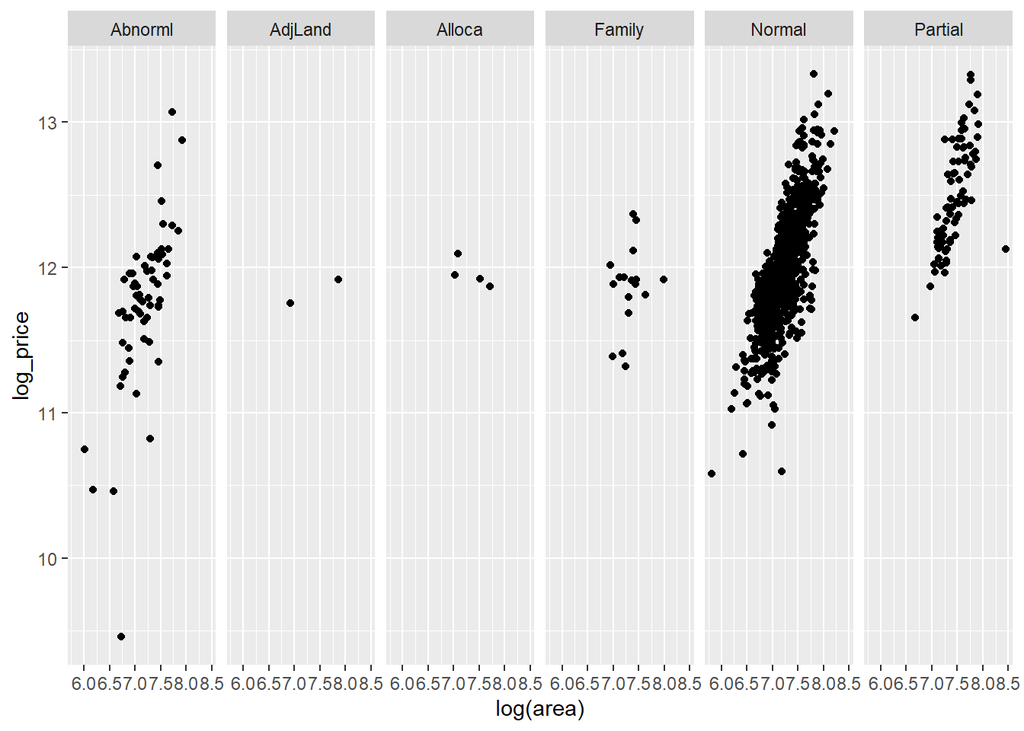

```r
ggplot(ames_train, aes(x=log(area), y= log_price)) + geom_point() + facet_grid(.~ Sale.Condition)
```

One thing is obvious from the above plot that Data becomes invalid when the Sale condition are anything other than Normal and Partial.

```r
ames_train <- ames_train %>% filter(Sale.Condition=="Normal" | Sale.Condition=="Partial")
```

```r
ames_train <-ames_train[complete.cases(ames_train$Bsmt.Qual),]
```

## 3.2 Age and Neighborhood

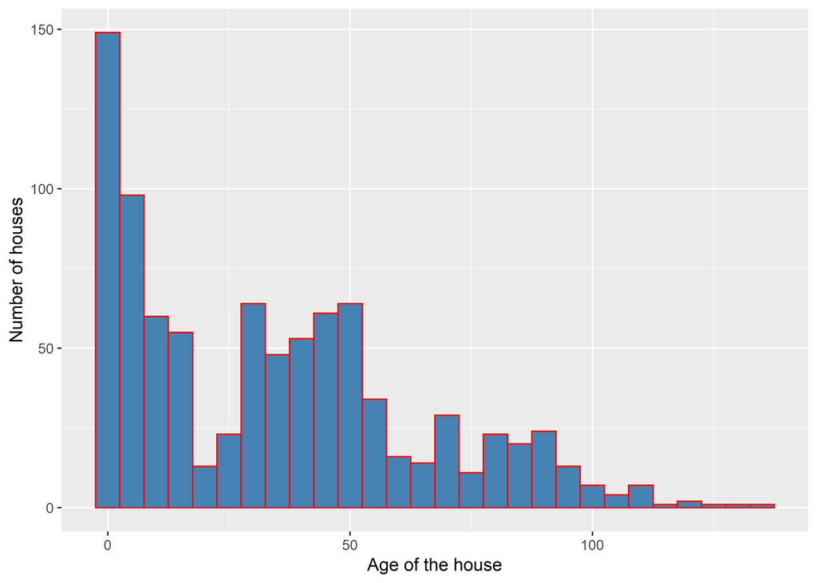

```r
ames_train <- ames_train %>% mutate(age=Yr.Sold - Year.Built)
ggplot(ames_train, aes(x=age))+ geom_histogram(fill="steelblue", color="red" , binwidth=5) + xlab("Age of the house") + ylab("Number of houses")
```

The distribution is right skewed.

The reason for that is that like everything house also has a lifetime and hence after a ling time, either it is rebuild or levelled down. Therfore houses with an old age are less is number.

The distribution of houses is multimodal since it has more than 1 peak.

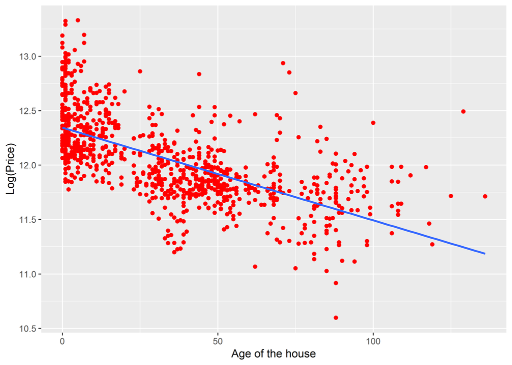

```r
ggplot(ames_train, aes(x=age, y= log_price))+ geom_point(fill="steelblue", color="red") + xlab("Age of the house") + ylab("Log(Price)") + stat_smooth(method = "lm", se= FALSE)
```

The corelation between log(price) and age of a house is negative which means that as the age of the house increrases its price decreases. There are outliers on both sides on the linearly regressed fitted line.

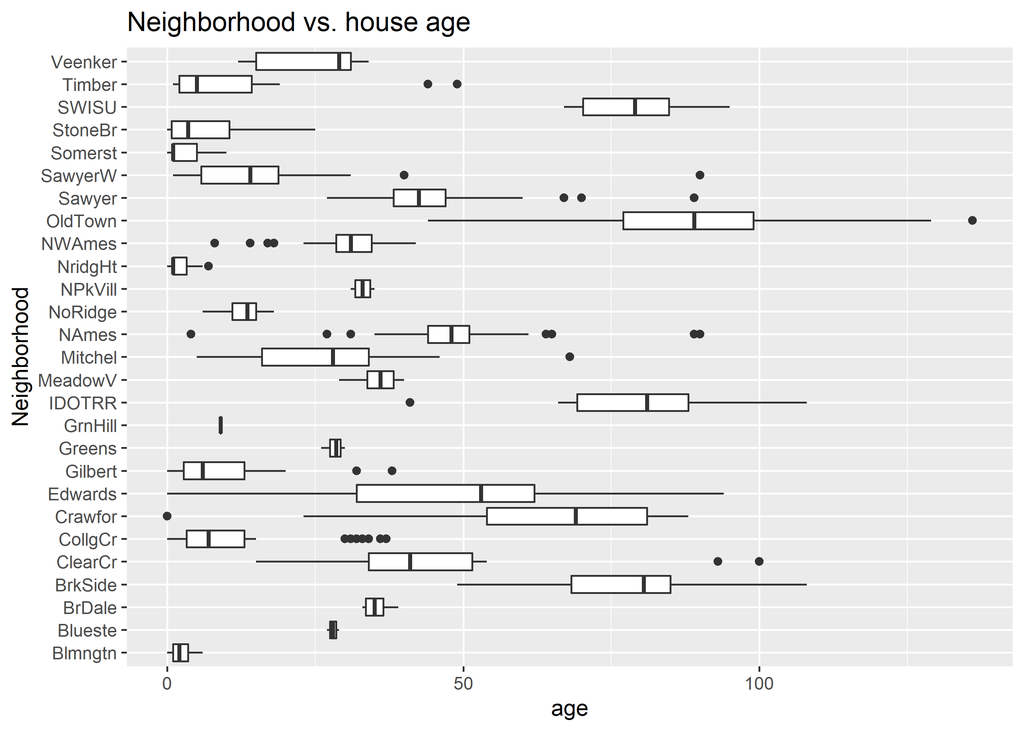

```r
ggplot(ames_train, aes(x =Neighborhood, y = age)) + geom_boxplot() + coord_flip()+labs(title = 'Neighborhood vs. house age')
```

Summary Statistics to follow the graph.

```r
z1 <- ames_train %>% group_by(Neighborhood) %>% summarise(median_age=median(age)) %>% arrange(desc(median_age)) %>% print(n=27)
```

```
## # A tibble: 27 x 2
##    Neighborhood median_age
##    <fct>             <dbl>
##  1 OldTown            89
##  2 IDOTRR             81
##  3 BrkSide            80.5
##  4 SWISU              79
##  5 Crawfor            69
##  6 Edwards            53
##  7 NAmes              48
##  8 Sawyer             42.5
##  9 ClearCr            41
## 10 MeadowV            36
## 11 BrDale             35
## 12 NPkVill            33
## 13 NWAmes             31
## 14 Veenker            29
## 15 Greens             28.5
## 16 Blueste            28
## 17 Mitchel            28
## 18 SawyerW            14
## 19 NoRidge            13.5
## 20 GrnHill             9
## 21 CollgCr             7
## 22 Gilbert             6
## 23 Timber              5
## 24 StoneBr             3.5
## 25 Blmngtn             2
## 26 NridgHt             1
## 27 Somerst             1
```

```r
x1 <- ames_train %>% group_by(Neighborhood) %>% summarise(sd_age=sd(age)) %>% arrange(desc(sd_age))
x1
```

```
## # A tibble: 27 x 2
##    Neighborhood sd_age
##    <fct>         <dbl>
##  1 ClearCr        26.5
##  2 Edwards        24.9
##  3 Crawfor        22.5
##  4 OldTown        20.3
##  5 SawyerW        15.4
##  6 Timber         14.2
##  7 Mitchel        13.4
##  8 IDOTRR         13.0
##  9 BrkSide        11.8
## 10 Sawyer         11.1
## # ... with 17 more rows
```

## 3.3 Bsmt.Qual vs Bsmt.Cond; Garage.Qual vs Garage.Cond; Overall.Qual vs Overall.Cond

If we assume that the price of house does depend on Garage, Basement and Overall variable then our next dilemma is whether to consider, quality or condition. So to sort that out we will compare both the quality and condition with price and see which gives better results.

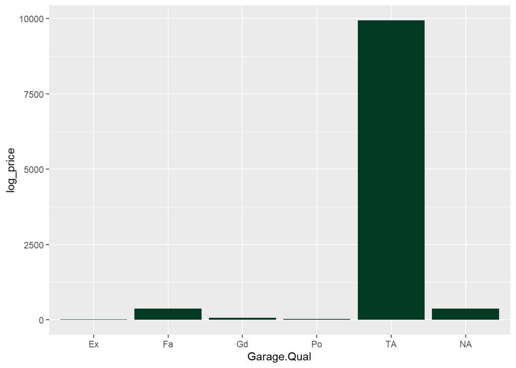

```r
ggplot(ames_train, aes(x=Garage.Qual, y= log_price))+
  geom_bar(stat="identity",fill = "#013B23")
```

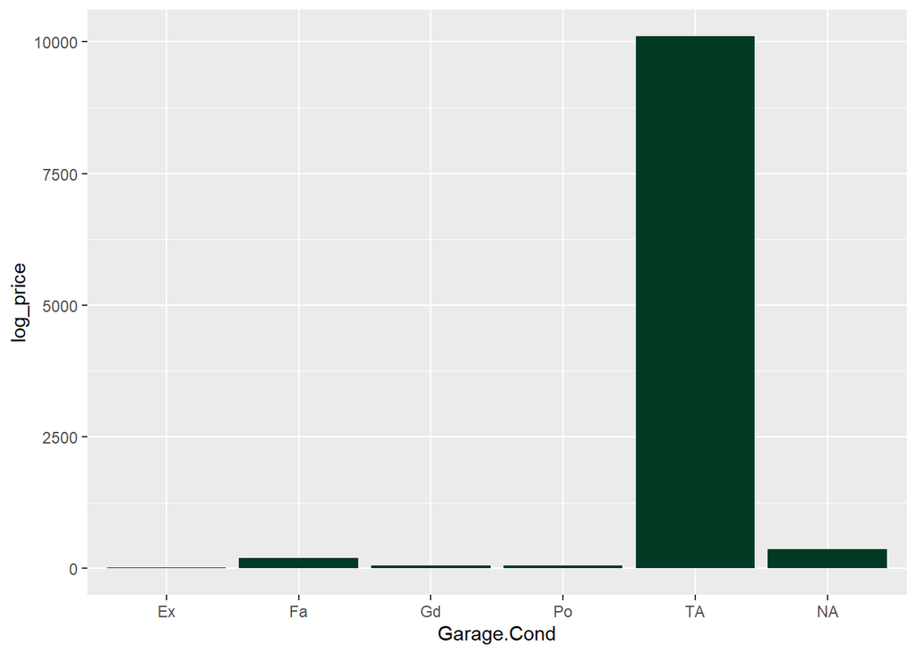

```r
ggplot(ames_train, aes(x=Garage.Cond, y= log_price))+
  geom_bar(stat="identity",fill = "#013B23")
```

```r
summary(ames_train $ Garage.Qual)
```

```
##        Ex   Fa   Gd   Po   TA NA's
##    0    1   32    6    3  822   32
```

```r
summary(ames_train $ Garage.Cond)
```

```
##        Ex   Fa   Gd   Po   TA NA's
##    0    1   17    5    5  836   32
```

From the plot and the summary statistics, one thing is evident that the value of these 2 variables is TA for more than 90% of the houses and therfore we will not consider them in the model.

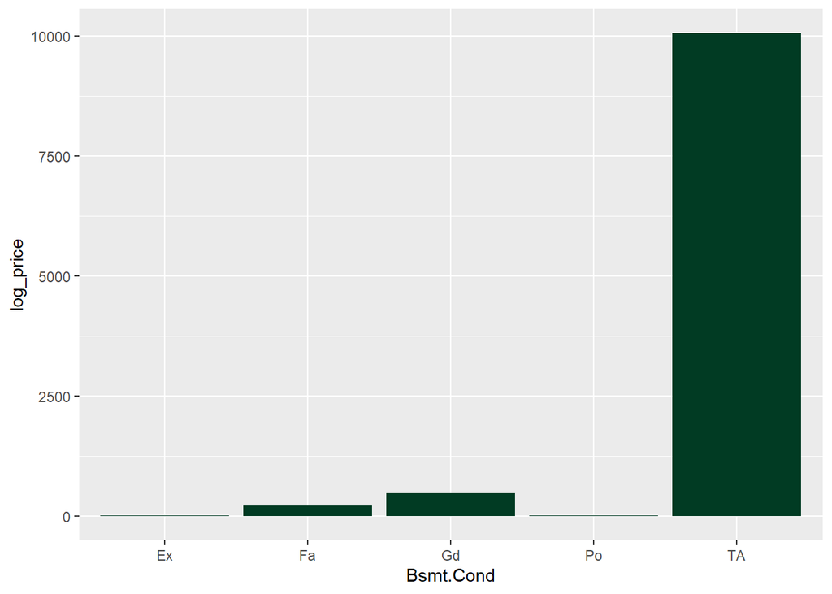

```r
ggplot(ames_train, aes(x=Bsmt.Cond, y= log_price)) +
   geom_bar(stat="identity",fill = "#013B23")
```

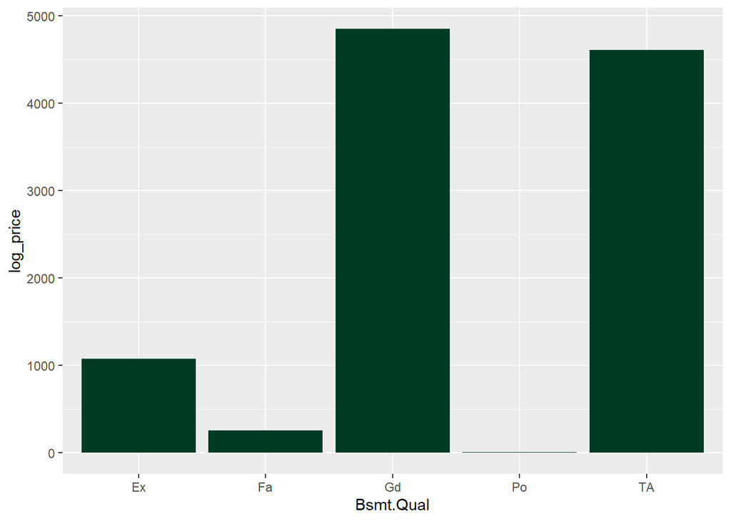

```r
ggplot(ames_train, aes(x=Bsmt.Qual, y= log_price)) +
   geom_bar(stat="identity",fill = "#013B23")
```

```r
summary(ames_train $ Bsmt.Qual)
```

```
##      Ex  Fa  Gd  Po  TA
##   0  85  22 398   1 390
```

```r
summary(ames_train $ Bsmt.Cond)
```

```
##      Ex  Fa  Gd  Po  TA
##   0   2  19  39   1 835
```

From the plot and the summary statistics, one thing is evident that Bsmt.Cond is useless variable because it takes the value TA for more than 90% of the houses.But Bsmt.Qual takes meaningful values and it might have an impact on the model hence we’ll consider it on our model.

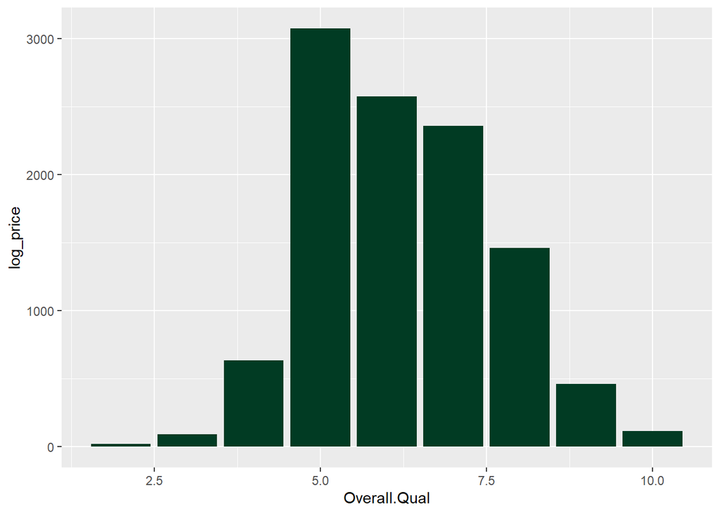

```r
ames_train <- ames_train %>%
mutate(Bsmt.Qual=ifelse(is.na(Bsmt.Qual),"Missing",Bsmt.Qual))
ggplot(ames_train, aes(x=Overall.Qual, y= log_price)) + geom_bar(stat="identity",fill = "#013B23")
```

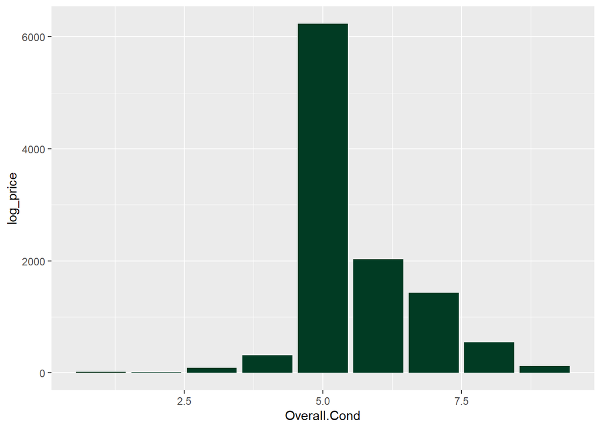

```r
ggplot(ames_train, aes(x=Overall.Cond, y= log_price)) + geom_bar(stat="identity",fill = "#013B23")
```

```r
summary(ames_train $Overall.Qual)
```

```
##    Min. 1st Qu.  Median    Mean 3rd Qu.    Max.
##   2.000   5.000   6.000   6.188   7.000  10.000
```

```r
summary(ames_train $ Overall.Cond)
```

```
##    Min. 1st Qu.  Median    Mean 3rd Qu.    Max.
##   1.000   5.000   5.000   5.597   6.000   9.000
```

From the plot it cam be seen that the both the distributions are almost Normal with log(price) and hence we need to find the distribution of residuals.

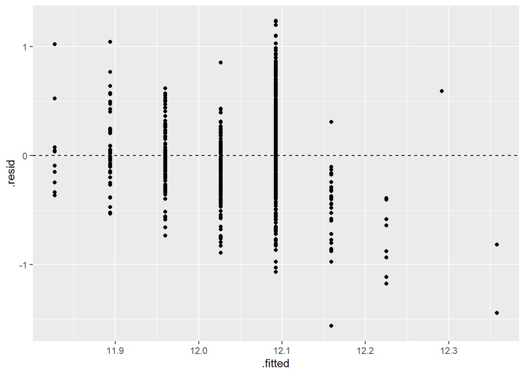

```r
q1<- lm(log_price ~ Overall.Cond, data=ames_train)
w1<- lm(log_price ~ Overall.Qual, data=ames_train)
ggplot(data=q1, aes(x=.fitted, y=.resid)) + geom_point() + geom_hline(yintercept=0, linetype="dashed")
```

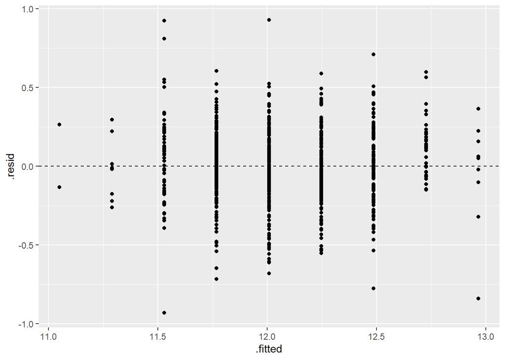

```r
ggplot(data=w1, aes(x=.fitted, y=.resid)) + geom_point() + geom_hline(yintercept=0, linetype="dashed")
```

The residuals of Overall.Qual are normally distributed hence we will include Overall.Qual in our model.

## 3.4 (X1st.Flr.SF + x2nd.Flr.Sf) vs price and Area vs Price

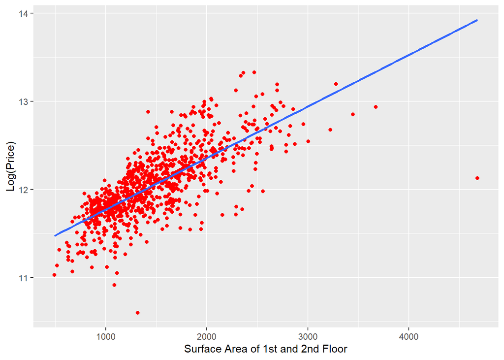

```r
ames_train<- ames_train %>% mutate(SF=X1st.Flr.SF + X2nd.Flr.SF)
ggplot(ames_train, aes(x=SF, y= log_price))+ geom_point(fill="steelblue", color="red") + xlab("Surface Area of 1st and 2nd Floor") + ylab("Log(Price)") + stat_smooth(method = "lm", se= FALSE)
```

From the plot it can be seen that SF and log_price have a strong positive linear relationship.

There are 2 outliers in the plot, both of them have very less price as compared to the linear model.

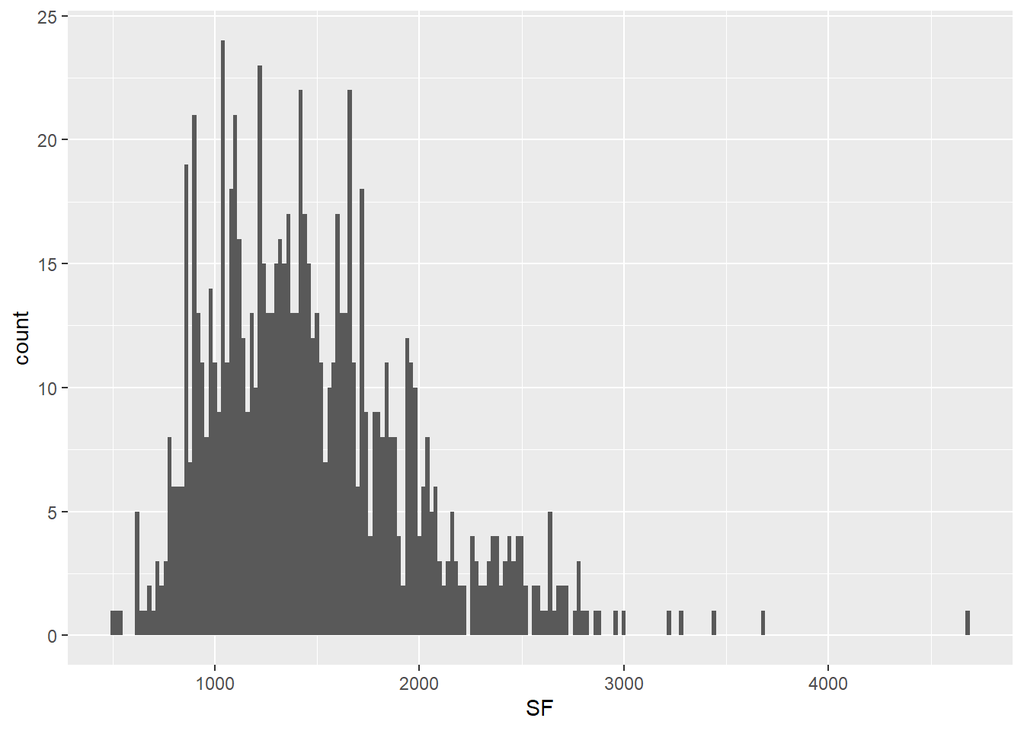

```r
ggplot(ames_train, aes(x=SF)) + geom_bar(binwidth = 20)
```

```r
summary(ames_train $ SF)
```

```
##    Min. 1st Qu.  Median    Mean 3rd Qu.    Max.
##     492    1093    1412    1482    1747    4676
```

The distribution is right skewed and hence transfroming it to log(SF) seems reasonable.

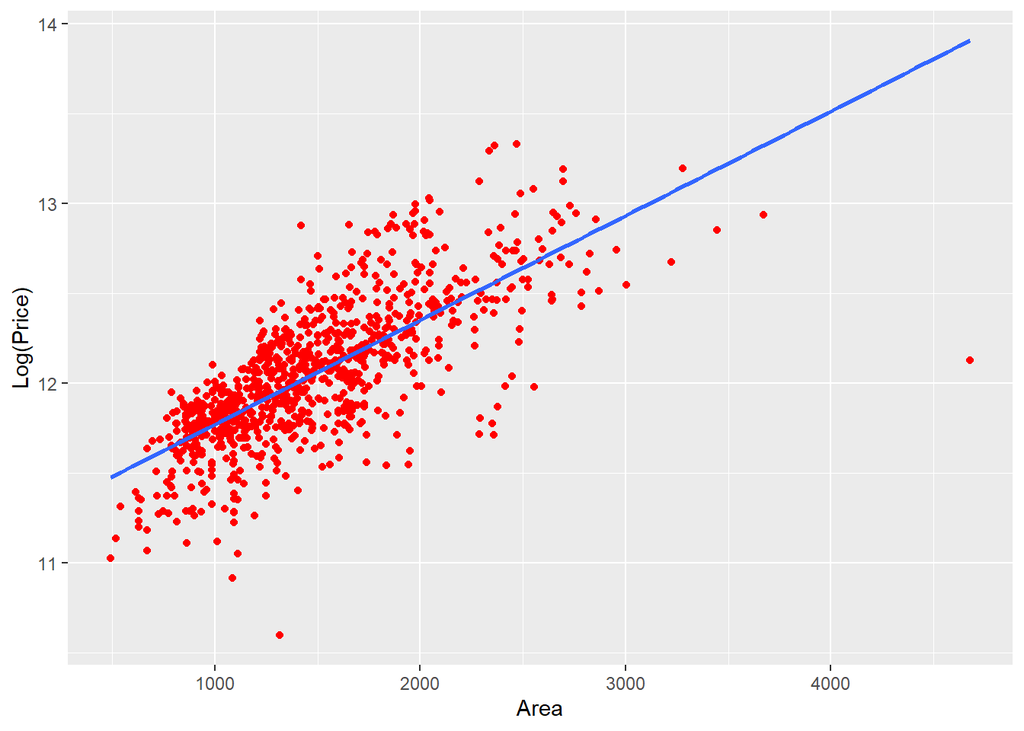

```r
ggplot(ames_train, aes(x=area, y= log_price))+ geom_point(fill="steelblue", color="red") + xlab("Area") + ylab("Log(Price)") + stat_smooth(method = "lm", se= FALSE)
```

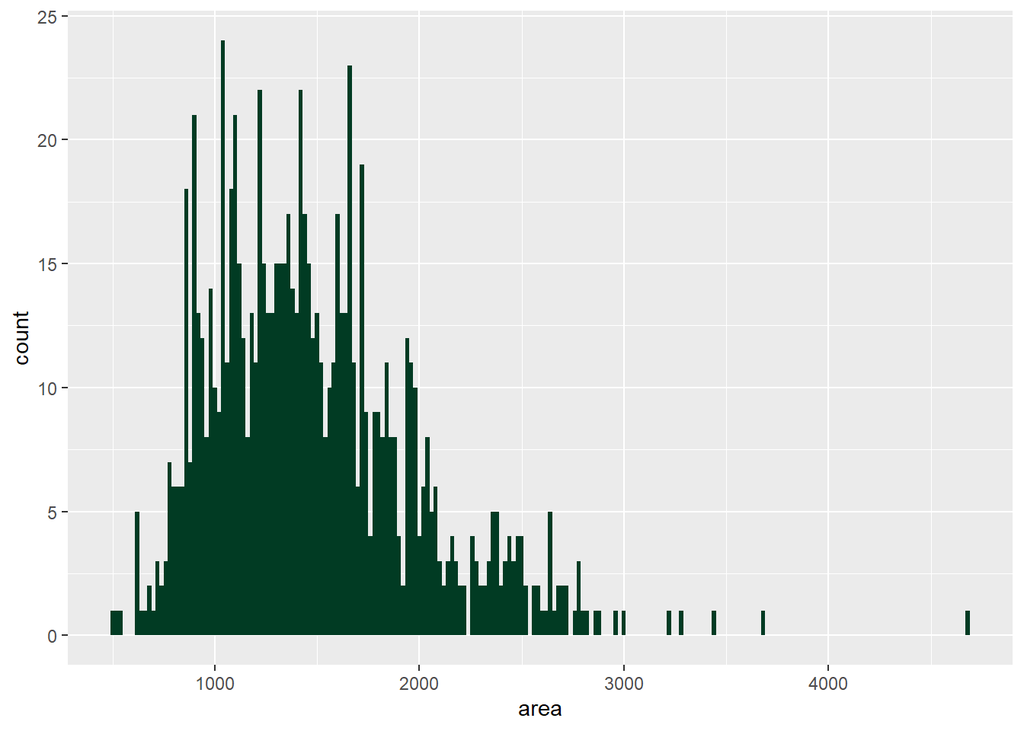

```r
ggplot(ames_train, aes(x=area)) + geom_bar(binwidth = 20,fill = "#013B23")
```

```r
summary(ames_train $ SF)
```

```
##    Min. 1st Qu.  Median    Mean 3rd Qu.    Max.
##     492    1093    1412    1482    1747    4676
```

The distribution is right skewed and hence transfroming it to log(area) seems reasonable.

```r
ames_train <- ames_train %>% mutate(log_area=log(area))
```

## 3.5 Price vs Kitchen Quality, Price vs heating.QC

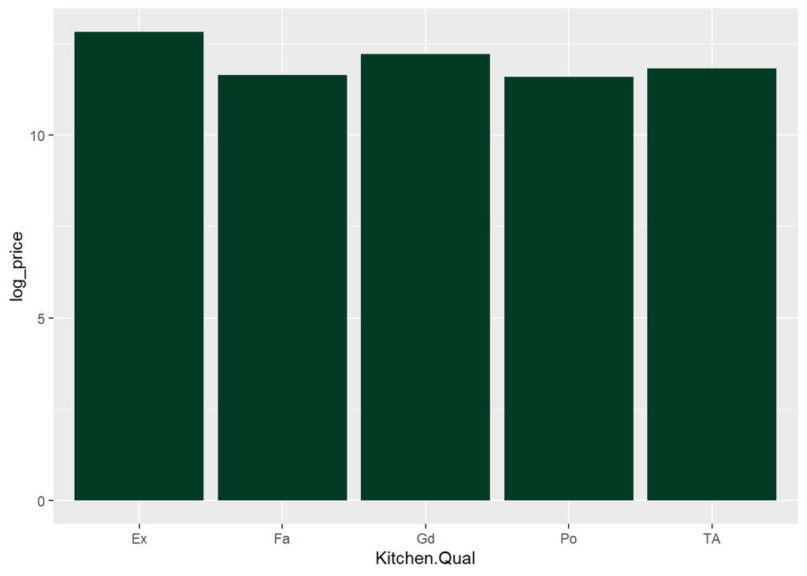

```r
ggplot(ames_train, aes(x=Kitchen.Qual, y= log_price)) +
   stat_summary(fun.y="median", geom="bar",fill = "#013B23")
```

```r
kitchen_price<-lm(log_price~ Kitchen.Qual, data=ames_train)
summary(kitchen_price)
```

```
##
## Call:
## lm(formula = log_price ~ Kitchen.Qual, data = ames_train)
##
## Residuals:
##      Min       1Q   Median       3Q      Max
## -1.21781 -0.14803 -0.00141  0.17161  1.05588
##
## Coefficients:
##                Estimate Std. Error t value Pr(>|t|)
## (Intercept)    12.72930    0.03585 355.113  < 2e-16 ***
## Kitchen.QualFa -1.14793    0.07915 -14.504  < 2e-16 ***
## Kitchen.QualGd -0.49461    0.03864 -12.801  < 2e-16 ***
## Kitchen.QualPo -1.14405    0.28452  -4.021 6.29e-05 ***
## Kitchen.QualTA -0.91486    0.03832 -23.874  < 2e-16 ***
## ---
## Signif. codes:  0 '***' 0.001 '**' 0.01 '*' 0.05 '.' 0.1 ' ' 1
##
## Residual standard error: 0.2823 on 891 degrees of freedom
## Multiple R-squared:  0.4946, Adjusted R-squared:  0.4924
## F-statistic:   218 on 4 and 891 DF,  p-value: < 2.2e-16
```

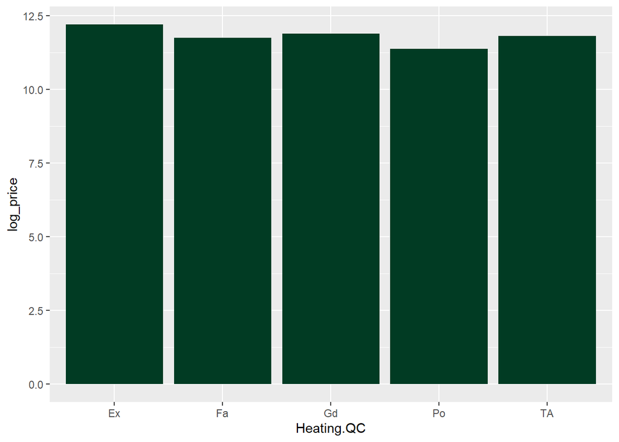

```r
ggplot(ames_train, aes(x=Heating.QC, y= log_price)) +
   stat_summary(fun.y="median", geom="bar",fill = "#013B23")
```

```r
heating_price<-lm(log_price~ Kitchen.Qual, data=ames_train)
summary(heating_price)
```

```
##
## Call:
## lm(formula = log_price ~ Kitchen.Qual, data = ames_train)
##
## Residuals:
##      Min       1Q   Median       3Q      Max
## -1.21781 -0.14803 -0.00141  0.17161  1.05588
##
## Coefficients:
##                Estimate Std. Error t value Pr(>|t|)
## (Intercept)    12.72930    0.03585 355.113  < 2e-16 ***
## Kitchen.QualFa -1.14793    0.07915 -14.504  < 2e-16 ***
## Kitchen.QualGd -0.49461    0.03864 -12.801  < 2e-16 ***
## Kitchen.QualPo -1.14405    0.28452  -4.021 6.29e-05 ***
## Kitchen.QualTA -0.91486    0.03832 -23.874  < 2e-16 ***
## ---
## Signif. codes:  0 '***' 0.001 '**' 0.01 '*' 0.05 '.' 0.1 ' ' 1
##
## Residual standard error: 0.2823 on 891 degrees of freedom
## Multiple R-squared:  0.4946, Adjusted R-squared:  0.4924
## F-statistic:   218 on 4 and 891 DF,  p-value: < 2.2e-16
```

For every level in both the variables, Kitchen.Qual and Heating.QC, there is a small difference in the median house price.

Even though the difference here seems small,the variables might have considerable effect on price and hence we’ll consider them in the model.

# 4 Development and Assessment of an Initial model

Before we start modelling we need to make sure that the ames_Test and ames_Train data set have the same variables with the same levels and to ensure that we’ll define a function called modify.

```r
ModifyDataSet <- function(x) { x %>%

filter(Sale.Condition %in% c("Normal","Partial")) %>% filter(Foundation!="Wood")%>%
    filter(Neighborhood != "Landmrk") %>% filter(House.Style!="2.5Fin")%>%
    mutate(Bsmt.Qual=ifelse(is.na(Bsmt.Qual),"Missing",Bsmt.Qual))

}
ames_train1 <- ModifyDataSet(ames_train)
```

## 4.1 An Initial Model

For log_price ,the ten predictors selected are log_area, Age, SF, Overall.Qual, Bsmt.Qual, Foundation,Bath, log(Lot.Area), Heating.QC and Neighborhood. log_area, Age, SF are added to the dataset. I am assuming log(Lot.Area) and Bath might have some impact on the price and hence I have included them in the model.

```r
Initial_Model <- lm(log_price ~log_area  + age+ log(SF)+  Overall.Qual+ Bsmt.Qual+ Foundation+Bath+ log(Lot.Area)+ Neighborhood+Heating.QC, data=ames_train1 )
summary(Initial_Model)
```

```
##
## Call:
## lm(formula = log_price ~ log_area + age + log(SF) + Overall.Qual +
##     Bsmt.Qual + Foundation + Bath + log(Lot.Area) + Neighborhood +
##     Heating.QC, data = ames_train1)
##
## Residuals:
##      Min       1Q   Median       3Q      Max
## -1.02302 -0.07006 -0.00068  0.06899  0.68318
##
## Coefficients:
##                       Estimate Std. Error t value Pr(>|t|)
## (Intercept)          7.3591327  0.1679317  43.822  < 2e-16 ***
## log_area             0.3131395  0.1375128   2.277 0.023023 *
## age                 -0.0034032  0.0004267  -7.975 4.86e-15 ***
## log(SF)              0.1330209  0.1378556   0.965 0.334853
## Overall.Qual         0.0832953  0.0062192  13.393  < 2e-16 ***
## Bsmt.Qual           -0.0198152  0.0054780  -3.617 0.000315 ***
## FoundationCBlock     0.0221371  0.0208793   1.060 0.289335
## FoundationPConc      0.0272310  0.0234309   1.162 0.245485
## FoundationStone      0.1789622  0.0796635   2.246 0.024928 *
## Bath                -0.0337288  0.0105135  -3.208 0.001386 **
## log(Lot.Area)        0.1381732  0.0126800  10.897  < 2e-16 ***
## NeighborhoodBlueste -0.0348664  0.0890495  -0.392 0.695496
## NeighborhoodBrDale  -0.1362175  0.0677876  -2.009 0.044801 *
## NeighborhoodBrkSide -0.0199216  0.0542540  -0.367 0.713568
## NeighborhoodClearCr -0.0222069  0.0631944  -0.351 0.725371
## NeighborhoodCollgCr -0.0934143  0.0448565  -2.083 0.037592 *
## NeighborhoodCrawfor  0.1023003  0.0540461   1.893 0.058717 .
## NeighborhoodEdwards -0.1296289  0.0490124  -2.645 0.008323 **
## NeighborhoodGilbert -0.1402343  0.0477612  -2.936 0.003412 **
## NeighborhoodGreens   0.1191834  0.0805319   1.480 0.139254
## NeighborhoodGrnHill  0.3819926  0.1394652   2.739 0.006291 **
## NeighborhoodIDOTRR  -0.1550320  0.0565153  -2.743 0.006212 **
## NeighborhoodMeadowV -0.1392535  0.0558785  -2.492 0.012888 *
## NeighborhoodMitchel -0.0496430  0.0484713  -1.024 0.306044
## NeighborhoodNAmes   -0.0211860  0.0478155  -0.443 0.657820
## NeighborhoodNoRidge  0.0272362  0.0496155   0.549 0.583186
## NeighborhoodNPkVill -0.0007829  0.0803616  -0.010 0.992229
## NeighborhoodNridgHt  0.0853117  0.0458772   1.860 0.063290 .
## NeighborhoodNWAmes  -0.0358168  0.0502053  -0.713 0.475789
## NeighborhoodOldTown -0.0905426  0.0541427  -1.672 0.094832 .
## NeighborhoodSawyer  -0.0373949  0.0494141  -0.757 0.449399
## NeighborhoodSawyerW -0.1315228  0.0479287  -2.744 0.006194 **
## NeighborhoodSomerst -0.0063381  0.0439958  -0.144 0.885485
## NeighborhoodStoneBr  0.1108149  0.0520491   2.129 0.033536 *
## NeighborhoodSWISU   -0.0971024  0.0648568  -1.497 0.134715
## NeighborhoodTimber   0.0040218  0.0534712   0.075 0.940061
## NeighborhoodVeenker  0.0276555  0.0628619   0.440 0.660091
## Heating.QCFa        -0.1333212  0.0374686  -3.558 0.000394 ***
## Heating.QCGd        -0.0103012  0.0144938  -0.711 0.477446
## Heating.QCPo        -0.0527449  0.1367323  -0.386 0.699776
## Heating.QCTA        -0.0529641  0.0137774  -3.844 0.000130 ***
## ---
## Signif. codes:  0 '***' 0.001 '**' 0.01 '*' 0.05 '.' 0.1 ' ' 1
##
## Residual standard error: 0.133 on 855 degrees of freedom
## Multiple R-squared:  0.8924, Adjusted R-squared:  0.8873
## F-statistic: 177.2 on 40 and 855 DF,  p-value: < 2.2e-16
```

The adjusted R squre is .8873 which is preety good for an initial model. This means that roughly 88% values of the preicted values are explained by the model.

log_area, age,Overall.Quality and log(LOt.Area) are significant predictors of price of a house.

Since R square is preety high in the initial model itself, there are very good chances that overfitting might have happened.

## 4.2 Model Selection

Now we perform stepwise AIC and BIc on the intial model to find the best model.

It might be possible that BIC and AIC drop different parameters.

```r
Initial_Model.AIC <-stepAIC(Initial_Model,k=2)
```

```
## Start:  AIC=-3575.48
## log_price ~ log_area + age + log(SF) + Overall.Qual + Bsmt.Qual +
##     Foundation + Bath + log(Lot.Area) + Neighborhood + Heating.QC
##
##                 Df Sum of Sq    RSS     AIC
## - log(SF)        1    0.0165 15.135 -3576.5
## <none>                       15.119 -3575.5
## - Foundation     3    0.1044 15.223 -3575.3
## - log_area       1    0.0917 15.210 -3572.1
## - Bath           1    0.1820 15.301 -3566.8
## - Bsmt.Qual      1    0.2314 15.350 -3563.9
## - Heating.QC     4    0.4394 15.558 -3557.8
## - age            1    1.1247 16.244 -3513.2
## - log(Lot.Area)  1    2.0997 17.218 -3461.0
## - Neighborhood  26    3.4701 18.589 -3442.3
## - Overall.Qual   1    3.1719 18.291 -3406.8
##
## Step:  AIC=-3576.5
## log_price ~ log_area + age + Overall.Qual + Bsmt.Qual + Foundation +
##     Bath + log(Lot.Area) + Neighborhood + Heating.QC
##
##                 Df Sum of Sq    RSS     AIC
## <none>                       15.135 -3576.5
## - Foundation     3    0.1088 15.244 -3576.1
## - Bath           1    0.1783 15.313 -3568.0
## - Bsmt.Qual      1    0.2364 15.372 -3564.6
## - Heating.QC     4    0.4399 15.575 -3558.8
## - age            1    1.1155 16.251 -3514.8
## - log(Lot.Area)  1    2.1021 17.237 -3462.0
## - Neighborhood  26    3.4799 18.615 -3443.1
## - Overall.Qual   1    3.2524 18.388 -3404.1
## - log_area       1    4.7834 19.919 -3332.4
```

Only 1 parameter is dropped in stepwise AIC which is log(SF).

```r
Initial_Model.AIC<-lm(log_price ~ log_area + age + Overall.Qual + Bsmt.Qual + Bath+
    log(Lot.Area) + Neighborhood + Heating.QC+ Foundation, data=ames_train1)
summary(Initial_Model.AIC)
```

```
##
## Call:
## lm(formula = log_price ~ log_area + age + Overall.Qual + Bsmt.Qual +
##     Bath + log(Lot.Area) + Neighborhood + Heating.QC + Foundation,
##     data = ames_train1)
##
## Residuals:
##      Min       1Q   Median       3Q      Max
## -1.02251 -0.07021  0.00000  0.06933  0.68573
##
## Coefficients:
##                       Estimate Std. Error t value Pr(>|t|)
## (Intercept)          7.3736113  0.1672533  44.087  < 2e-16 ***
## log_area             0.4432563  0.0269491  16.448  < 2e-16 ***
## age                 -0.0033864  0.0004263  -7.943  6.2e-15 ***
## Overall.Qual         0.0839067  0.0061866  13.563  < 2e-16 ***
## Bsmt.Qual           -0.0200162  0.0054738  -3.657 0.000271 ***
## Bath                -0.0333603  0.0105062  -3.175 0.001550 **
## log(Lot.Area)        0.1382495  0.0126792  10.904  < 2e-16 ***
## NeighborhoodBlueste -0.0349305  0.0890459  -0.392 0.694953
## NeighborhoodBrDale  -0.1361955  0.0677849  -2.009 0.044826 *
## NeighborhoodBrkSide -0.0200385  0.0542517  -0.369 0.711949
## NeighborhoodClearCr -0.0214989  0.0631876  -0.340 0.733759
## NeighborhoodCollgCr -0.0932007  0.0448542  -2.078 0.038020 *
## NeighborhoodCrawfor  0.1030122  0.0540389   1.906 0.056951 .
## NeighborhoodEdwards -0.1296058  0.0490104  -2.644 0.008332 **
## NeighborhoodGilbert -0.1401029  0.0477590  -2.934 0.003441 **
## NeighborhoodGreens   0.1180519  0.0805201   1.466 0.142984
## NeighborhoodGrnHill  0.3821595  0.1394595   2.740 0.006266 **
## NeighborhoodIDOTRR  -0.1543627  0.0565088  -2.732 0.006431 **
## NeighborhoodMeadowV -0.1385754  0.0558719  -2.480 0.013321 *
## NeighborhoodMitchel -0.0492869  0.0484680  -1.017 0.309490
## NeighborhoodNAmes   -0.0209734  0.0478130  -0.439 0.661023
## NeighborhoodNoRidge  0.0276369  0.0496118   0.557 0.577630
## NeighborhoodNPkVill -0.0010293  0.0803580  -0.013 0.989784
## NeighborhoodNridgHt  0.0851837  0.0458752   1.857 0.063675 .
## NeighborhoodNWAmes  -0.0351656  0.0501987  -0.701 0.483789
## NeighborhoodOldTown -0.0927554  0.0540920  -1.715 0.086749 .
## NeighborhoodSawyer  -0.0367925  0.0494081  -0.745 0.456678
## NeighborhoodSawyerW -0.1313144  0.0479263  -2.740 0.006273 **
## NeighborhoodSomerst -0.0066023  0.0439931  -0.150 0.880741
## NeighborhoodStoneBr  0.1103076  0.0520443   2.119 0.034336 *
## NeighborhoodSWISU   -0.1021445  0.0646433  -1.580 0.114448
## NeighborhoodTimber   0.0038211  0.0534687   0.071 0.943044
## NeighborhoodVeenker  0.0277594  0.0628593   0.442 0.658882
## Heating.QCFa        -0.1329328  0.0374650  -3.548 0.000409 ***
## Heating.QCGd        -0.0093949  0.0144628  -0.650 0.516130
## Heating.QCPo        -0.0535239  0.1367244  -0.391 0.695545
## Heating.QCTA        -0.0527455  0.0137750  -3.829 0.000138 ***
## FoundationCBlock     0.0232147  0.0208486   1.113 0.265810
## FoundationPConc      0.0287630  0.0233761   1.230 0.218867
## FoundationStone      0.1809924  0.0796325   2.273 0.023283 *
## ---
## Signif. codes:  0 '***' 0.001 '**' 0.01 '*' 0.05 '.' 0.1 ' ' 1
##
## Residual standard error: 0.133 on 856 degrees of freedom
## Multiple R-squared:  0.8922, Adjusted R-squared:  0.8873
## F-statistic: 181.7 on 39 and 856 DF,  p-value: < 2.2e-16
```

R square remains same.

Next we do model selection by BIC.

```r
Initial_Model.BIC <-stepAIC(Initial_Model,k=log(10))
```

```
## Start:  AIC=-3563.07
## log_price ~ log_area + age + log(SF) + Overall.Qual + Bsmt.Qual +
##     Foundation + Bath + log(Lot.Area) + Neighborhood + Heating.QC
##
##                 Df Sum of Sq    RSS     AIC
## - log(SF)        1    0.0165 15.135 -3564.4
## - Foundation     3    0.1044 15.223 -3563.8
## <none>                       15.119 -3563.1
## - log_area       1    0.0917 15.210 -3560.0
## - Bath           1    0.1820 15.301 -3554.7
## - Bsmt.Qual      1    0.2314 15.350 -3551.8
## - Heating.QC     4    0.4394 15.558 -3546.6
## - age            1    1.1247 16.244 -3501.1
## - log(Lot.Area)  1    2.0997 17.218 -3448.9
## - Neighborhood  26    3.4701 18.589 -3437.8
## - Overall.Qual   1    3.1719 18.291 -3394.7
##
## Step:  AIC=-3564.4
## log_price ~ log_area + age + Overall.Qual + Bsmt.Qual + Foundation +
##     Bath + log(Lot.Area) + Neighborhood + Heating.QC
##
##                 Df Sum of Sq    RSS     AIC
## - Foundation     3    0.1088 15.244 -3564.9
## <none>                       15.135 -3564.4
## - Bath           1    0.1783 15.313 -3556.2
## - Bsmt.Qual      1    0.2364 15.372 -3552.8
## - Heating.QC     4    0.4399 15.575 -3547.9
## - age            1    1.1155 16.251 -3503.0
## - log(Lot.Area)  1    2.1021 17.237 -3450.2
## - Neighborhood  26    3.4799 18.615 -3438.8
## - Overall.Qual   1    3.2524 18.388 -3392.3
## - log_area       1    4.7834 19.919 -3320.6
##
## Step:  AIC=-3564.89
## log_price ~ log_area + age + Overall.Qual + Bsmt.Qual + Bath +
##     log(Lot.Area) + Neighborhood + Heating.QC
##
##                 Df Sum of Sq    RSS     AIC
## <none>                       15.244 -3564.9
## - Bath           1    0.1890 15.433 -3556.2
## - Bsmt.Qual      1    0.2328 15.477 -3553.6
## - Heating.QC     4    0.4759 15.720 -3546.6
## - age            1    1.3933 16.637 -3488.8
## - log(Lot.Area)  1    2.0975 17.341 -3451.7
## - Neighborhood  26    3.5212 18.765 -3438.6
## - Overall.Qual   1    3.4103 18.654 -3386.3
## - log_area       1    4.8794 20.123 -3318.4
```

2 parameters are dropped in stepwise BIC which are log(SF) and Foundation.

```r
Initial_Model.BIC<-lm(log_price ~ log_area + age + Overall.Qual + Bsmt.Qual +     Bath + log(Lot.Area) + Neighborhood + Heating.QC, data=ames_train1)
summary(Initial_Model.BIC)
```

```
##
## Call:
## lm(formula = log_price ~ log_area + age + Overall.Qual + Bsmt.Qual +
##     Bath + log(Lot.Area) + Neighborhood + Heating.QC, data = ames_train1)
##
## Residuals:
##      Min       1Q   Median       3Q      Max
## -1.02633 -0.07104 -0.00073  0.06910  0.66253
##
## Coefficients:
##                       Estimate Std. Error t value Pr(>|t|)
## (Intercept)          7.3765219  0.1668507  44.210  < 2e-16 ***
## log_area             0.4463167  0.0269162  16.582  < 2e-16 ***
## age                 -0.0034973  0.0003947  -8.861  < 2e-16 ***
## Overall.Qual         0.0853124  0.0061541  13.863  < 2e-16 ***
## Bsmt.Qual           -0.0194529  0.0053712  -3.622 0.000310 ***
## Bath                -0.0343106  0.0105140  -3.263 0.001145 **
## log(Lot.Area)        0.1374664  0.0126445  10.872  < 2e-16 ***
## NeighborhoodBlueste -0.0371792  0.0883643  -0.421 0.674044
## NeighborhoodBrDale  -0.1374235  0.0671844  -2.045 0.041113 *
## NeighborhoodBrkSide -0.0267374  0.0542809  -0.493 0.622439
## NeighborhoodClearCr -0.0233243  0.0630333  -0.370 0.711450
## NeighborhoodCollgCr -0.0920740  0.0449325  -2.049 0.040750 *
## NeighborhoodCrawfor  0.0982431  0.0539854   1.820 0.069136 .
## NeighborhoodEdwards -0.1288763  0.0487517  -2.644 0.008354 **
## NeighborhoodGilbert -0.1379409  0.0478155  -2.885 0.004014 **
## NeighborhoodGreens   0.1134877  0.0797905   1.422 0.155296
## NeighborhoodGrnHill  0.3836256  0.1397026   2.746 0.006158 **
## NeighborhoodIDOTRR  -0.1595383  0.0565594  -2.821 0.004902 **
## NeighborhoodMeadowV -0.1355032  0.0555013  -2.441 0.014830 *
## NeighborhoodMitchel -0.0470351  0.0483957  -0.972 0.331381
## NeighborhoodNAmes   -0.0186523  0.0472176  -0.395 0.692920
## NeighborhoodNoRidge  0.0280340  0.0496916   0.564 0.572793
## NeighborhoodNPkVill -0.0021080  0.0796840  -0.026 0.978901
## NeighborhoodNridgHt  0.0844808  0.0459555   1.838 0.066361 .
## NeighborhoodNWAmes  -0.0353479  0.0497914  -0.710 0.477947
## NeighborhoodOldTown -0.0914905  0.0541575  -1.689 0.091517 .
## NeighborhoodSawyer  -0.0357622  0.0490201  -0.730 0.465869
## NeighborhoodSawyerW -0.1298659  0.0480037  -2.705 0.006959 **
## NeighborhoodSomerst -0.0062217  0.0440723  -0.141 0.887768
## NeighborhoodStoneBr  0.1089443  0.0521146   2.090 0.036868 *
## NeighborhoodSWISU   -0.1077120  0.0647129  -1.664 0.096385 .
## NeighborhoodTimber   0.0034371  0.0534681   0.064 0.948760
## NeighborhoodVeenker  0.0274725  0.0627217   0.438 0.661492
## Heating.QCFa        -0.1358453  0.0374990  -3.623 0.000309 ***
## Heating.QCGd        -0.0073536  0.0144205  -0.510 0.610223
## Heating.QCPo        -0.0439865  0.1363540  -0.323 0.747084
## Heating.QCTA        -0.0528109  0.0133592  -3.953 8.35e-05 ***
## ---
## Signif. codes:  0 '***' 0.001 '**' 0.01 '*' 0.05 '.' 0.1 ' ' 1
##
## Residual standard error: 0.1332 on 859 degrees of freedom
## Multiple R-squared:  0.8915, Adjusted R-squared:  0.8869
## F-statistic:   196 on 36 and 859 DF,  p-value: < 2.2e-16
```

R square becomes .8869 which is almost same to the Initial Model.

## 4.3 Initial Model Residuals

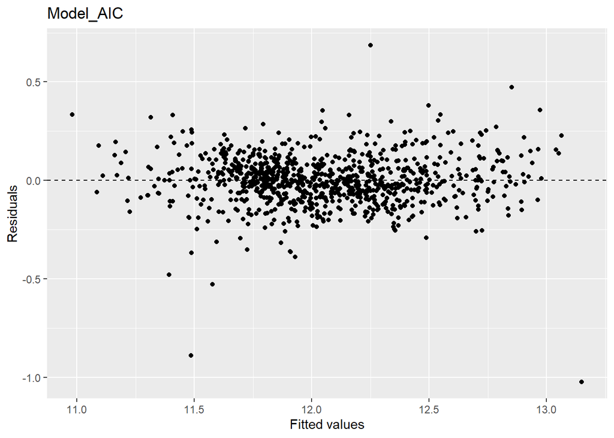

```r
ggplot(data = Initial_Model.AIC, aes(x = .fitted, y = .resid)) +
  geom_point() +
  geom_hline(yintercept = 0, linetype = "dashed") +
  xlab("Fitted values") +
  ylab("Residuals")+ ggtitle( "Model_AIC")
```

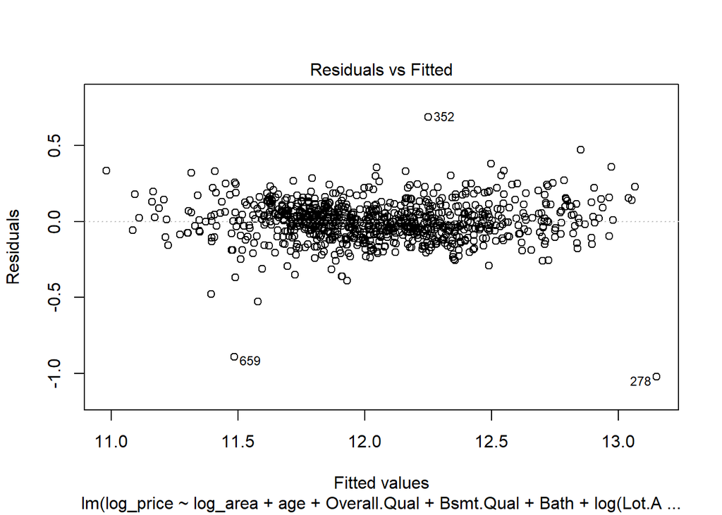

```r
plot(Initial_Model.AIC, which = 1, add.smooth = F)
```

```r
library(car)
outlierTest(Initial_Model.AIC)
```

```
##      rstudent unadjusted p-value Bonferroni p
## 278 -8.359544         2.5369e-16   2.2680e-13
## 659 -7.057343         3.5091e-12   3.1371e-09
## 352  5.442231         6.8756e-08   6.1468e-05
## 457 -4.105465         4.4219e-05   3.9532e-02
```

```r
outlierTest(Initial_Model.BIC)
```

```
##      rstudent unadjusted p-value Bonferroni p
## 278 -8.368348         2.3568e-16   2.1070e-13
## 659 -7.114347         2.3727e-12   2.1212e-09
## 352  5.196530         2.5387e-07   2.2696e-04
```

## 4.4 Initial Model RMSE

RMSE for Initial model.

```r
Initial_Model.AIC.resid <- ames_train1$price - exp(predict(Initial_Model.AIC, ames_train1))
Initial_Model.AIC.rmse <- sqrt(mean(Initial_Model.AIC.resid^2))
Initial_Model.AIC.rmse
```

```
## [1] 29287.07
```

```r
Initial_Model.BIC.resid <- ames_train1$price - exp(predict(Initial_Model.BIC, ames_train1))
Initial_Model.BIC.rmse <- sqrt(mean(Initial_Model.BIC.resid^2))
Initial_Model.BIC.rmse
```

```
## [1] 29356.91
```

RMSE for the AIC model is less compared to BIC one and even the R square value of AIC Model is slightly more than the BIC model.

## 4.5 Overfitting

The process of building a model generally involves starting with an initial model , identifying its shortcomings, and adapting the model accordingly. This process may be repeated several times until the model fits the data reasonably well. However, the model may do well on training data but perform poorly out-of-sample (meaning, on a dataset other than the original training data) because the model is overly-tuned to specifically fit the training data. This is called “overfitting.” To determine whether overfitting is occurring on a model, we compare the performance of a model on both in-sample and out-of-sample data sets. To look at performance of my initial model on out-of-sample data, I will use the data set `ames_test`.

```r
load("ames_test.Rdata")
```

I’ll find the RMSE value of our model using test file and compare it with the value we got earlier from the train data.

But before data we need to perfom all the operations we performed on training data set to the testing data set and also add the variables we created.

```r
ames_test1<-ModifyDataSet(ames_test)
```

```r
Testing.resid <- ames_test1$price - exp(predict(Initial_Model.AIC, ames_test1))
Testing.rmse <- sqrt(mean(Testing.resid^2))
Testing.rmse
```

```
## [1] 25510.67
```

```r
Testing.resid <- ames_test1$price - exp(predict(Initial_Model.BIC, ames_test1))
Testing.rmse <- sqrt(mean(Testing.resid^2))
Testing.rmse
```

```
## [1] 25444.71
```

It is usually expected that since the model fits the training data better, the RMSE value for the training data set would be smaller than RMSE value for the testing data set but in our case the situation is different.

In our case the RMSE for the Test Data is less than the Train data.

# 5 Development of a Final Model

Now that I have developed an initial model to use as a baseline, I’ll create a final model with at most 20 variables to predict housing prices in Ames, IA, selecting from the full array of variables in the dataset.

## 5.1 Final Model

```r
Final_Model <- lm(log_price ~log_area  + age + log(SF) +  Overall.Qual + Bsmt.Qual+ Foundation+ log(Lot.Area)+ Neighborhood+Heating.QC +House.Style+ Kitchen.Qual+Central.Air+Bldg.Type+Bath+TotRms.AbvGrd, data=ames_train1 )
summary(Final_Model)
```

```
##
## Call:
## lm(formula = log_price ~ log_area + age + log(SF) + Overall.Qual +
##     Bsmt.Qual + Foundation + log(Lot.Area) + Neighborhood + Heating.QC +
##     House.Style + Kitchen.Qual + Central.Air + Bldg.Type + Bath +
##     TotRms.AbvGrd, data = ames_train1)
##
## Residuals:
##      Min       1Q   Median       3Q      Max
## -1.02088 -0.06704  0.00245  0.06593  0.55780
##
## Coefficients:
##                       Estimate Std. Error t value Pr(>|t|)
## (Intercept)          7.2024169  0.2145630  33.568  < 2e-16 ***
## log_area             0.3186614  0.1314366   2.424 0.015542 *
## age                 -0.0022177  0.0004166  -5.323 1.31e-07 ***
## log(SF)              0.1970648  0.1297310   1.519 0.129133
## Overall.Qual         0.0667522  0.0060959  10.950  < 2e-16 ***
## Bsmt.Qual           -0.0136457  0.0053117  -2.569 0.010371 *
## FoundationCBlock     0.0250933  0.0196489   1.277 0.201926
## FoundationPConc      0.0353925  0.0219846   1.610 0.107801
## FoundationStone      0.1915208  0.0742256   2.580 0.010042 *
## log(Lot.Area)        0.0810386  0.0142271   5.696 1.70e-08 ***
## NeighborhoodBlueste  0.0740425  0.0851325   0.870 0.384696
## NeighborhoodBrDale  -0.0607923  0.0672684  -0.904 0.366399
## NeighborhoodBrkSide -0.0060384  0.0525692  -0.115 0.908579
## NeighborhoodClearCr  0.0464737  0.0607081   0.766 0.444174
## NeighborhoodCollgCr -0.0771152  0.0432371  -1.784 0.074860 .
## NeighborhoodCrawfor  0.1111421  0.0509647   2.181 0.029478 *
## NeighborhoodEdwards -0.1197381  0.0466223  -2.568 0.010393 *
## NeighborhoodGilbert -0.0982492  0.0462657  -2.124 0.033997 *
## NeighborhoodGreens   0.1767588  0.0754432   2.343 0.019365 *
## NeighborhoodGrnHill  0.4368646  0.1289221   3.389 0.000735 ***
## NeighborhoodIDOTRR  -0.1499020  0.0541054  -2.771 0.005720 **
## NeighborhoodMeadowV -0.1234286  0.0538948  -2.290 0.022258 *
## NeighborhoodMitchel -0.0307474  0.0468093  -0.657 0.511448
## NeighborhoodNAmes   -0.0399628  0.0457673  -0.873 0.382819
## NeighborhoodNoRidge  0.0556614  0.0476161   1.169 0.242751
## NeighborhoodNPkVill  0.0194240  0.0767808   0.253 0.800346
## NeighborhoodNridgHt  0.0929127  0.0437817   2.122 0.034115 *
```

[output cut: 21 more lines]

```
## Kitchen.QualPo      -0.1640651  0.1352099  -1.213 0.225314
## Kitchen.QualTA      -0.1293470  0.0244516  -5.290 1.56e-07 ***
## Central.AirY         0.1622662  0.0252533   6.426 2.20e-10 ***
## Bldg.Type2fmCon     -0.0006183  0.0333207  -0.019 0.985199
## Bldg.TypeDuplex     -0.0999804  0.0310670  -3.218 0.001339 **
## Bldg.TypeTwnhs      -0.0929806  0.0333329  -2.789 0.005399 **
## Bldg.TypeTwnhsE     -0.0744287  0.0214982  -3.462 0.000563 ***
## Bath                 0.0082809  0.0110032   0.753 0.451907
## TotRms.AbvGrd       -0.0005759  0.0052313  -0.110 0.912374
## ---
## Signif. codes:  0 '***' 0.001 '**' 0.01 '*' 0.05 '.' 0.1 ' ' 1
##
## Residual standard error: 0.1223 on 839 degrees of freedom
## Multiple R-squared:  0.9107, Adjusted R-squared:  0.9047
## F-statistic: 152.8 on 56 and 839 DF,  p-value: < 2.2e-16
```

R square has increased to .9047 .

```r
Final_Model.AIC <-stepAIC(Final_Model,k=2)
```

```
## Start:  AIC=-3710.69
## log_price ~ log_area + age + log(SF) + Overall.Qual + Bsmt.Qual +
##     Foundation + log(Lot.Area) + Neighborhood + Heating.QC +
##     House.Style + Kitchen.Qual + Central.Air + Bldg.Type + Bath +
##     TotRms.AbvGrd
##
##                 Df Sum of Sq    RSS     AIC
## - TotRms.AbvGrd  1   0.00018 12.545 -3712.7
## - Bath           1   0.00847 12.553 -3712.1
## - Heating.QC     4   0.11248 12.657 -3710.7
## <none>                       12.545 -3710.7
## - log(SF)        1   0.03450 12.579 -3710.2
## - Foundation     3   0.12497 12.670 -3707.8
## - log_area       1   0.08789 12.633 -3706.4
## - Bsmt.Qual      1   0.09868 12.643 -3705.7
## - Bldg.Type      4   0.36455 12.909 -3693.0
## - Kitchen.Qual   4   0.48954 13.034 -3684.4
## - age            1   0.42373 12.969 -3682.9
## - log(Lot.Area)  1   0.48513 13.030 -3678.7
## - Central.Air    1   0.61734 13.162 -3669.7
## - House.Style    6   0.98010 13.525 -3655.3
## - Overall.Qual   1   1.79292 14.338 -3593.0
## - Neighborhood  26   2.93210 15.477 -3574.5
##
## Step:  AIC=-3712.68
## log_price ~ log_area + age + log(SF) + Overall.Qual + Bsmt.Qual +
##     Foundation + log(Lot.Area) + Neighborhood + Heating.QC +
##     House.Style + Kitchen.Qual + Central.Air + Bldg.Type + Bath
##
##                 Df Sum of Sq    RSS     AIC
## - Bath           1   0.00845 12.553 -3714.1
## - Heating.QC     4   0.11241 12.657 -3712.7
## <none>                       12.545 -3712.7
## - log(SF)        1   0.03463 12.580 -3712.2
## - Foundation     3   0.12537 12.670 -3709.8
## - log_area       1   0.08872 12.634 -3708.4
## - Bsmt.Qual      1   0.09999 12.645 -3707.6
## - Bldg.Type      4   0.36466 12.910 -3695.0
## - Kitchen.Qual   4   0.49031 13.035 -3686.3
## - age            1   0.42399 12.969 -3684.9
```

[output cut: 11 more lines]

```
##                 Df Sum of Sq    RSS     AIC
## <none>                       12.553 -3714.1
## - Heating.QC     4   0.11310 12.667 -3714.0
## - log(SF)        1   0.03501 12.588 -3713.6
## - Foundation     3   0.12248 12.676 -3711.4
## - log_area       1   0.09330 12.647 -3709.4
## - Bsmt.Qual      1   0.10340 12.657 -3708.7
## - Bldg.Type      4   0.35701 12.911 -3697.0
## - Kitchen.Qual   4   0.48874 13.042 -3687.9
## - age            1   0.45545 13.009 -3684.1
## - log(Lot.Area)  1   0.48385 13.037 -3682.2
## - Central.Air    1   0.62509 13.179 -3672.5
## - House.Style    6   1.11838 13.672 -3649.6
## - Overall.Qual   1   1.79104 14.345 -3596.6
## - Neighborhood  26   2.93424 15.488 -3577.9
```

The number of variables returned by AIC are 13 , that means 2 variables are dropped by AIC and those are Bath and TotRms.AbvGrd.

```r
Final_Model.AIC <- lm(log_price ~log_area + age + log(SF) + Overall.Qual + Bsmt.Qual +
    Foundation + log(Lot.Area) + Neighborhood + Heating.QC +
    House.Style + Kitchen.Qual + Central.Air + Bldg.Type
, data=ames_train1 )
summary(Final_Model.AIC)
```

```
##
## Call:
## lm(formula = log_price ~ log_area + age + log(SF) + Overall.Qual +
##     Bsmt.Qual + Foundation + log(Lot.Area) + Neighborhood + Heating.QC +
##     House.Style + Kitchen.Qual + Central.Air + Bldg.Type, data = ames_train1)
##
## Residuals:
##      Min       1Q   Median       3Q      Max
## -1.01735 -0.06676  0.00314  0.06549  0.56830
##
## Coefficients:
##                       Estimate Std. Error t value Pr(>|t|)
## (Intercept)          7.1718877  0.1871383  38.324  < 2e-16 ***
## log_area             0.3236508  0.1294544   2.500 0.012605 *
## age                 -0.0022689  0.0004107  -5.524 4.42e-08 ***
## log(SF)              0.1984599  0.1295828   1.532 0.126014
## Overall.Qual         0.0667017  0.0060893  10.954  < 2e-16 ***
## Bsmt.Qual           -0.0139041  0.0052828  -2.632 0.008645 **
## FoundationCBlock     0.0248394  0.0196272   1.266 0.206021
## FoundationPConc      0.0350785  0.0219513   1.598 0.110415
## FoundationStone      0.1891014  0.0740677   2.553 0.010853 *
## log(Lot.Area)        0.0808717  0.0142044   5.693 1.72e-08 ***
## NeighborhoodBlueste  0.0671337  0.0844901   0.795 0.427085
## NeighborhoodBrDale  -0.0611986  0.0672088  -0.911 0.362780
## NeighborhoodBrkSide -0.0076642  0.0522190  -0.147 0.883348
## NeighborhoodClearCr  0.0466289  0.0604846   0.771 0.440970
## NeighborhoodCollgCr -0.0762775  0.0429036  -1.778 0.075785 .
## NeighborhoodCrawfor  0.1116013  0.0507394   2.199 0.028114 *
## NeighborhoodEdwards -0.1198750  0.0462604  -2.591 0.009727 **
## NeighborhoodGilbert -0.0952012  0.0458745  -2.075 0.038266 *
## NeighborhoodGreens   0.1727731  0.0747303   2.312 0.021021 *
## NeighborhoodGrnHill  0.4374544  0.1286417   3.401 0.000704 ***
## NeighborhoodIDOTRR  -0.1502357  0.0537410  -2.796 0.005299 **
## NeighborhoodMeadowV -0.1235190  0.0538074  -2.296 0.021945 *
## NeighborhoodMitchel -0.0308844  0.0464623  -0.665 0.506412
## NeighborhoodNAmes   -0.0403639  0.0454395  -0.888 0.374634
## NeighborhoodNoRidge  0.0558806  0.0472847   1.182 0.237623
## NeighborhoodNPkVill  0.0242771  0.0763856   0.318 0.750698
## NeighborhoodNridgHt  0.0934260  0.0436875   2.139 0.032763 *
## NeighborhoodNWAmes  -0.0450475  0.0472765  -0.953 0.340939
```

[output cut: 18 more lines]

```
## Kitchen.QualFa      -0.1057092  0.0407930  -2.591 0.009726 **
## Kitchen.QualGd      -0.0714592  0.0209136  -3.417 0.000664 ***
## Kitchen.QualPo      -0.1581346  0.1348624  -1.173 0.241303
## Kitchen.QualTA      -0.1281354  0.0243164  -5.270 1.74e-07 ***
## Central.AirY         0.1630878  0.0252019   6.471 1.65e-10 ***
## Bldg.Type2fmCon     -0.0010338  0.0331148  -0.031 0.975102
## Bldg.TypeDuplex     -0.0973336  0.0300090  -3.243 0.001227 **
## Bldg.TypeTwnhs      -0.0918896  0.0328656  -2.796 0.005293 **
## Bldg.TypeTwnhsE     -0.0737330  0.0208224  -3.541 0.000420 ***
## ---
## Signif. codes:  0 '***' 0.001 '**' 0.01 '*' 0.05 '.' 0.1 ' ' 1
##
## Residual standard error: 0.1222 on 841 degrees of freedom
## Multiple R-squared:  0.9106, Adjusted R-squared:  0.9049
## F-statistic: 158.7 on 54 and 841 DF,  p-value: < 2.2e-16
```

There is very small increase in R square, to .9049 .

## 5.2 Variable Interaction

I did not include any vaiable interations in my model but there are chances of varible intereaction in this dataset.

## 5.3 Variable Selection

I used stepwise AIC and BIC to find the best model. I used this method beacuse they are based on the importance of a variable which is measured by p-value.

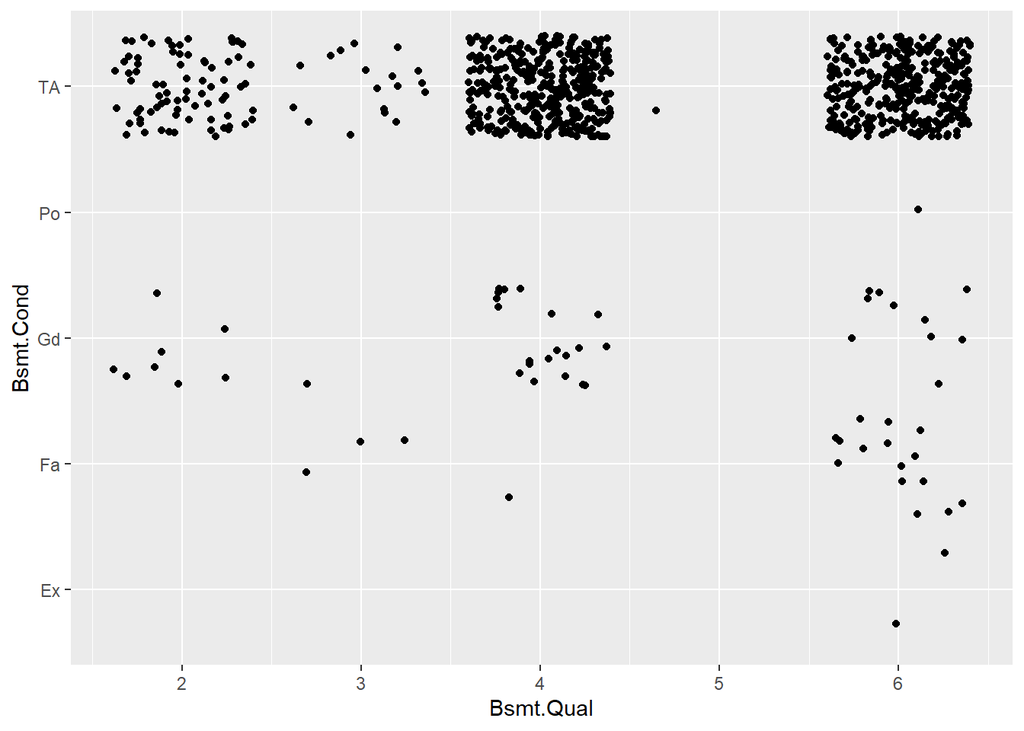

```r
ggplot(data = ames_train, aes(x = Bsmt.Qual, y =Bsmt.Cond))+ geom_jitter(color = "black")
```

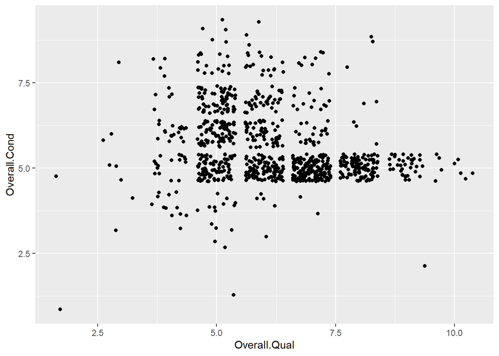

```r
ggplot(data = ames_train, aes(x = Overall.Qual, y =Overall.Cond))+ geom_jitter(color = "black")
```

If we had included both Bsmt.Qual and Bsmt.Cond in our model then we might have had a problem . The independent variables included in the model should not depend on any other variable in the model.

## 5.4 Model Testing

There were many variables which had differnt levels in testing and training data set and therfore we had to define a function first which only considered the fixed number of levels in a variable. For eg. Training Data set no value in level called Wood in Foundation but the Testing data did, which created error while testing the model. Same way for Landmrk in Neighbourhood and 2.5Fin in House.Style.

# 6 Final Model Assessment

## 6.1 Final Model Residual

To understand the residuals, I created an informative plot of the residuals.

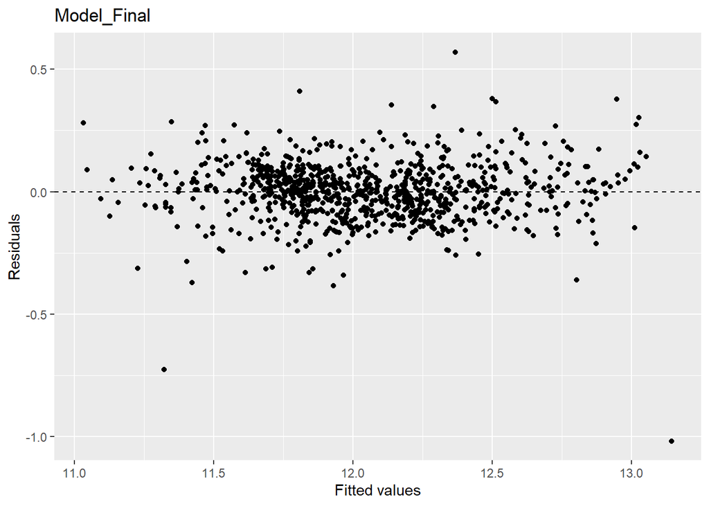

```r
ggplot(data = Final_Model.AIC, aes(x = .fitted, y = .resid)) +
  geom_point() +
  geom_hline(yintercept = 0, linetype = "dashed") +
  xlab("Fitted values") +
  ylab("Residuals")+ ggtitle( "Model_Final")
```

```r
library(car)
outlierTest(Final_Model.AIC)
```

```
##      rstudent unadjusted p-value Bonferroni p
## 278 -9.207433         2.6024e-19   2.3239e-16
## 659 -6.344216         3.6508e-10   3.2601e-07
## 352  5.164382         3.0142e-07   2.6917e-04
```

The outliers are same as the Intial model, therefore from this we can conclude that these 3 points are outliers for the whole data set and can be removed.

## 6.2 Final Model RMSE

```r
Final_Model.AIC.resid <- ames_train1$price - exp(predict(Final_Model.AIC, ames_train1))
Final_Model.AIC.rmse <- sqrt(mean(Final_Model.AIC.resid^2))
Final_Model.AIC.rmse
```

```
## [1] 27097.95
```

Compared to the RMSE for initial model the RMSE has substantially reduced. This justifies that the Final model is the better model.

```r
Testing.Final.resid <- ames_test1$price - exp(predict(Final_Model.AIC, ames_test1))
Testing.Final.rmse <- sqrt(mean(Testing.Final.resid^2))
Testing.Final.rmse
```

```
## [1] 23509.44
```

## 6.3 Final Model Evaluation

Strenghts: The R square value of my final model is .9049 which is preety good and hence my model can be used to predict data. The RMSE value for Testing is lower than that for Training which is not usual but that means that my model is not overfitting the data.

Weakness:I have adapted/changes the Testing data according to the training data and hence I won’t be able to predict value for a house from the testing data set with Neighbourhood as Landmrk or a house with House.Style as 2.5Fin or a House with Foundation as Wood.

## 6.4 Final Model Validation

```r
load("ames_validation.Rdata")
```

```r
ames_validation1<-ModifyDataSet(ames_validation)
```

```r
Validation.Final.resid <- ames_validation1$price - exp(predict(Final_Model.AIC, ames_validation1))
Validation.Final.rmse <- sqrt(mean(Validation.Final.resid^2))
Validation.Final.rmse
```

```
## [1] 21545.67
```

RMSE of the Final model with Validation data is even less than the RMSE of the final model with training as well as the testing data.

```r
Interval_95 <- predict(Final_Model.AIC, ames_validation1, interval = "prediction", level = 0.95)
Coverage.Prob.95 <- mean(exp(ames_validation1$log_price) > exp(Interval_95[,"lwr"]) & (exp(ames_validation1$log_price)) < exp(Interval_95[,"upr"]))
Coverage.Prob.95
```

```
## [1] 0.9616963
```

This means that 96.2% of the predicted home prices from the validation data set are in the 95% confidence interval of the actual home price.

Coverage Probability of 96% means that our model is good.

# 7 Conclusion

Even though logically Bath seemed like a very important variable but when compared to other varibles it is ignored.

In Linear modelling, most important step is Explaraoty Data Analysis.

Before starting modelling, it is very important to check whether we should transform any variable or not.

While creating a big model which is supposed to be used for predicting some values, it is very important to be thorough with the levels in each variable so you can easily adapt your data according to the testing data set.